# ENS 495 Fall 2017 Independent Data Analysis: Example Outline

## TITLE: Relationship between Pileated Woodpecker (Dryocopus pileatus) abundance and forest cover in Pennsylvania: An analysis using USGS Breeding Bird Survey data

## ABSTRACT

I found a significant positive relationshp between Pileated Woodpecker abundance on BBS routes and both mixed and deciduous forest cover. The relationship was mixed for, however, was much steeper and had a better fit to the data.

## INTRODUCTION

[your paper does not need an introduction]

## METHODS

[your paper does not need to have any field methods]

### STATISTICAL METHODS

The relationship between forest cover and the abundance of Pileated Woodpecker on each BBS route was modeled using linear regression in R (R Core Team 2017). Modeles were evaluated using hypothesis tests and AIC.

## RESULTS

### Hypothesis testing

There was a significant relationship between the number of Pileated Woodpeckers observed on a BBS route and both the percentage of deciduous forest cover (F = 10.61, P = 0.0014) and mixed forest cover (F = 44.55, P < 0.0001). Both relationships were positive but the slope of the mixed forest regression was much steeper (slope = 16.12, SE = 2.4) than the deciduous forest regression (slope = 1.58, SE = 0.48). Moreover, the mixed forest regression had a larger R^2 than the deciduous forest model (mixed forest R^2 = 0.24; deciduous forest R^2 = 0.066) and also a much lower AIC value (deciduous versus mixed delta AIC = 28.7)

## DISCUSSION

[your paper does not need a discussion]

## AKNOWLEDGEMENT

[skip]

## FIGURES

### Figure 1

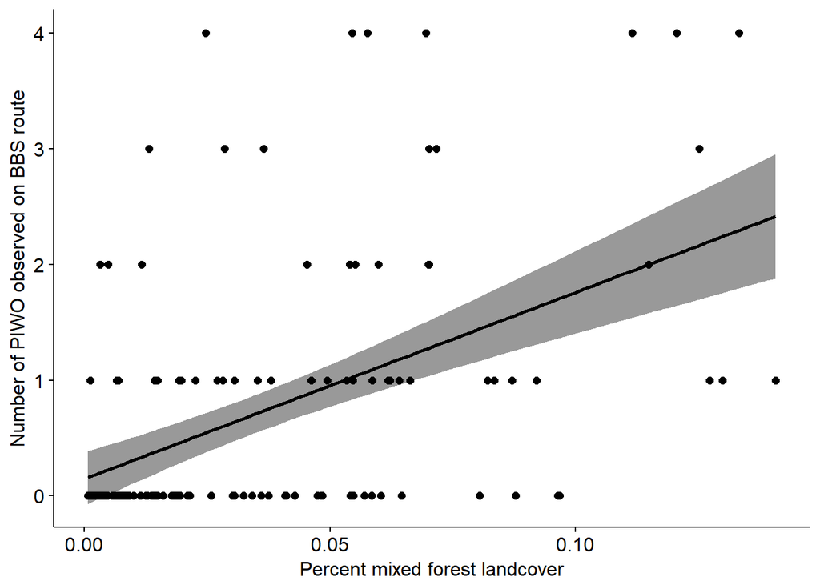

### Figure 1 caption

Relationship between the percent of mixed forest cover around a BBS route and the number of Pileated Woodpeckers (Dryocopus pileatus) observed. Error band = 95% confidence interval.

## APPENDICES

### Appendix 2: Exploratory graphs

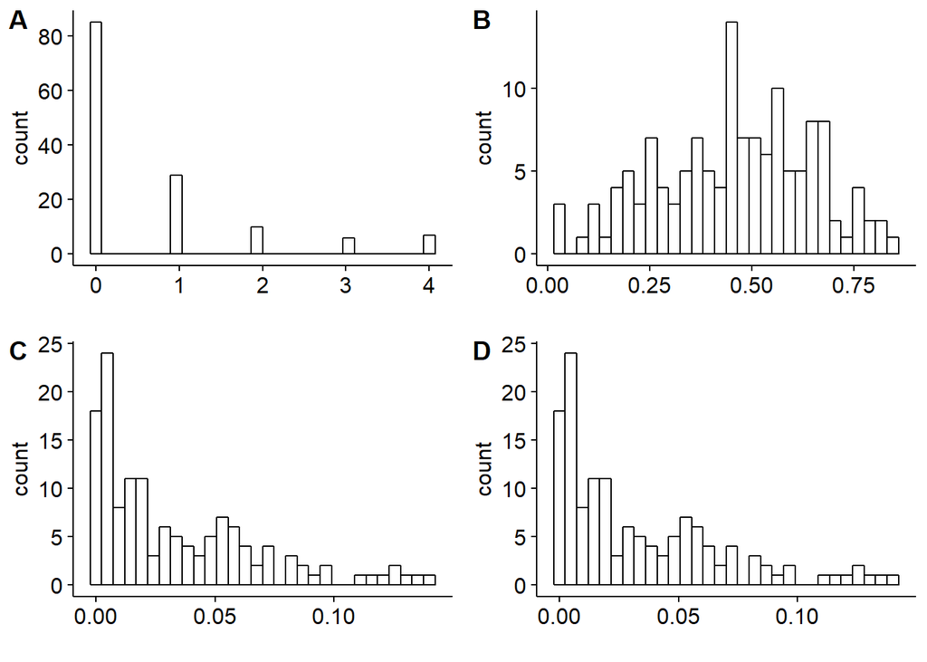

#### Exploratory graphs: histograms

[figure not shown]

## SUPLEMENTAL FILES

### Supplemental File 1: Raw data file:

Raw data is contained in Brouwer_NL_PIWO_vs_forest_cover.csv

### Supplemental file 2: Data analysis script

All code to reproduce these analyses is in the script file BROUWER_NL_analysis_script_PIWO_vs_forest_cover.R